# Оценка удельных сопротивлений тканей по сигналам боковых сборок

Этот ноутбук объединяет логику получения базовых $\rho_1,\rho_2$, их дыхательных и пульсовых изменений. Он служит входом в серию 33: объясняет математические переходы, показывает, что уже выполнено, и связывает оставшиеся вопросы с подробными расчётами. Состояние источников зафиксировано **14 сентября 2026 года**.

**Главный результат разбора.** При заданных толщине слоя и геометрии одно измеренное значение импеданса задаёт семейство допустимых пар сопротивлений. Несколько сборок позволяют проверить совместимость этих ограничений. Получение единственной устойчивой пары, а затем двух её изменений требует дополнительных условий, которые ещё не проверены для всей экспериментальной цепочки.

Здесь приведены кривые для сохранённых базовых уровней эксперимента 2 и отдельная синтетическая иллюстрация пульсовой задачи. Они восстанавливают способ рассуждения; точность реальных тканевых параметров ими не установлена. Подробная сводка доказательств и задач остаётся в документе 34.05. Применение выбранной в 20.16 геометрической модели 4 с конечными электродами к реальным боковым измерениям эксперимента 2 (Ник) представлено в 33.08 — применение КТ-модели к боковым измерениям. Расчёт предназначен для базовых ρ на вдохе и выдохе и пульсовых δρ, а также контрольного сравнения с полной КТ-моделью при тех же конечных электродах; статус — исследовательский.

Задача этого разбора — восстановить вычислительную последовательность и отделить полученные результаты от её незакрытых звеньев. Критерий завершения разбора: для каждого перехода указаны вход, модельное условие, наблюдаемый результат и оставшаяся проверка; кривые и прямые воспроизводятся из объявленных данных. Это критерий данного отчёта, а не завершения всей методики.

## 1. Как связаны этапы

Сначала из записей выбираются независимые измерения и принимается разметка дыхания. На её основе получают базовый импеданс каждой сборки в сопоставляемых состояниях. Затем к этим уровням применяют прямую модель, исследуют семейства решений и только после проверки совместимости оценивают параметры тканей. Дыхательные изменения определяются между двумя базовыми состояниями. Пульсовые изменения требуют отдельной временной привязки и линеаризации около выбранного базового состояния.

**Таблица 1.** Этапы расчёта и передаваемые результаты.

| Этап | Что он передаёт дальше | Основной материал |
| --- | --- | --- |
| Происхождение и проверка записей | Независимые записи, прибор, размеры, технические ограничения | 10.01 |
| Разметка и проверка сигналов | Принятые дыхательные интервалы, события ЭКГ, исключения | Дыхание, ЭКГ, сводная проверка |
| Прямая модель и анатомические входы | Оператор импеданса, геометрия и выбранное описание толщины | 30.01, роль КТ |
| Базовые параметры | Условные оценки сопротивлений и диагностика их определимости | Статическая оценка, диагностика, исследовательский расчёт |
| Пульсовые изменения | Сопоставимые ансамбли и два условных тканевых вклада | 33.03, 33.04 |
| Проверка и сокращение входов | Ошибки, границы применимости, обоснование выбора сборок | 34.05 |

Это порядок научных зависимостей. Он не означает, что все перечисленные ноутбуки уже образуют согласованную последовательность автоматического запуска.

## 2. Что измерено и что принято в модели

Для сборки $j$ обозначим базовый передаточный импеданс через $Z_j$ (Ом), полное расстояние между токовыми электродами через $L_j=2a_j$ (м), а координату потенциального электрода относительно центра через $b_j$ (м). В используемой симметричной схеме токовые электроды находятся в $\pm a_j$, потенциальные — в $\pm b_j$; в иллюстрациях $b_j/a_j=0{,}5$. Толщина верхнего слоя $h$ измеряется в метрах. Удельные сопротивления обоих слоёв $\rho_1,\rho_2$ выражаются в Ом·м.

**Экспериментальные входы.** Используются сохранённые агрегаты базового сигнала второго канала реокардиомонитора МГТУ. Это медианы на принятых интервалах задержек дыхания, а не мгновенные отсчёты. Сами интервалы восстановлены ретроспективно; прибор не записывал команды протокола. У Ника исключена перезаписанная копия размера 100 мм; у Георга этот размер независим. Физические единицы записей принимаются по решению автора как рабочее допущение. Выявленные проблемы конкретных каналов и записей при этом сохраняют силу.

**Модельные допущения.** Верхний слой представляет эффективную среду грудной стенки, нижний — лёгкое. Плоская граница и точечные электроды не воспроизводят рёбра, кривизну, конечные контакты и всю неоднородность анатомии. Последовательные записи разных размеров считаются сопоставимыми по физиологическому состоянию. Это условия расчёта, а не установленные свойства всех записей.

**Толщина в этом отчёте — заданный сценарий.** Она не измерена здесь по КТ и не оценена из показанных кривых. На этапе разработки индивидуальная КТ должна служить референсом для толщины либо её пространственного описания. Возможность заменить этот вход электрической оценкой остаётся самостоятельным вопросом.

Ниже встроена компактная копия агрегатов из сохранённого артефакта версии 1. Она позволяет воспроизвести иллюстрации без исходных сигналов. Текущая редакция 33.06 уже предусматривает статический артефакт версии 2 и новый атлас, но этот прогон не подтверждён сохранёнными результатами на момент извлечения. Новая редакция текста не приписывается старому артефакту.

В таблице 2 показаны оба дыхательных уровня. По ним можно проверить, какое наблюдение задаёт каждую кривую последующих рисунков.

**Таблица 2.** Сохранённые медианы базового импеданса; 19 независимых записей. Каждая строка соответствует одной независимой записи размерного ряда. Единицы приняты по рабочему решению автора; анатомическая интерпретация требует модели.

| Испытуемый | Размер, мм | После вдоха, Ом | После выдоха, Ом |
| --- | --- | --- | --- |
| Георг | 50 | 199.4810 | 194.1695 |
| Георг | 60 | 207.6260 | 200.5170 |
| Георг | 70 | 175.2770 | 171.2110 |
| Георг | 80 | 182.3375 | 176.9660 |
| Георг | 90 | 150.8750 | 147.0420 |
| Георг | 100 | 155.9025 | 151.8200 |
| Георг | 110 | 141.8180 | 138.0280 |
| Георг | 120 | 134.2090 | 128.7270 |
| Георг | 130 | 130.4210 | 125.6410 |
| Георг | 140 | 115.9150 | 111.6360 |
| Ник | 50 | 85.6890 | 83.1340 |
| Ник | 60 | 101.1020 | 97.4400 |
| Ник | 70 | 88.6780 | 85.6330 |
| Ник | 80 | 83.9430 | 79.6300 |
| Ник | 90 | 74.5730 | 70.3270 |
| Ник | 110 | 65.5810 | 61.4740 |
| Ник | 120 | 62.8210 | 57.6850 |
| Ник | 130 | 60.9250 | 55.7840 |
| Ник | 140 | 50.1030 | 46.8280 |

## 3. Одно значение импеданса задаёт кривую решений

Обозначим прямую двуслойную модель через $F$. Для одной сборки при фиксированных $h,a_j,b_j$ искомые сопротивления удовлетворяют уравнению

$$F(\rho_1,\rho_2;h,a_j,b_j)=Z_j^{\mathrm{набл}}, \tag{1}$$

где $Z_j^{\mathrm{набл}}$ — сохранённый базовый уровень сборки $j$, а $F$ — её модельный передаточный импеданс. Уравнение (1) задаёт ограничение, а не готовую пару сопротивлений.

Это одно уравнение с двумя неизвестными. Выбор одной пары оптимизатором сам по себе не устраняет множество других допустимых пар.

Модель однородна по сопротивлениям: одновременное умножение $\rho_1$ и $\rho_2$ на положительное число во столько же раз меняет импеданс. Поэтому удобно ввести безразмерное отношение $r=\rho_2/\rho_1$ и геометрический коэффициент $K_j(r;h)$, выраженный в м$^{-1}$:

$$F(\rho_1,r\rho_1;h,a_j,b_j)=\rho_1 K_j(r;h), \tag{2}$$

где $r$ — отношение сопротивлений, а $K_j$ — коэффициент связи для заданных отношения, толщины и геометрии. Свойство однородности в формуле (2) позволяет строить семейство без отдельной подгонки каждой его точки.

Для каждого положительного $r$, при котором коэффициент ненулевой и знак согласован с наблюдением, получаем точку семейства:

$$\rho_1(r)=\frac{Z_j^{\mathrm{набл}}}{K_j(r;h)},\qquad \rho_2(r)=r\frac{Z_j^{\mathrm{набл}}}{K_j(r;h)}, \tag{3}$$

где $\rho_1(r)$ и $\rho_2(r)$ — координаты одной точки кривой при выбранном отношении $r$.

Перебор $r$ строит именно искомую зависимость **$\rho_1$ от $\rho_2$ при заданном измеренном $Z$**. Коэффициент вычисляется существующей прямой моделью; отдельная копия её ряда здесь не вводится. Положительное отношение не ограничено случаем $\rho_2>\rho_1$. Конечная сетка отношений и окно рисунка являются техническими границами иллюстрации.

Рисунок 1 нужен для проверки наглядного смысла уравнения (3): разные сопротивления могут соответствовать одному наблюдению. Следующая ячейка строит такое семейство и проверяет выбранные точки обратной подстановкой.

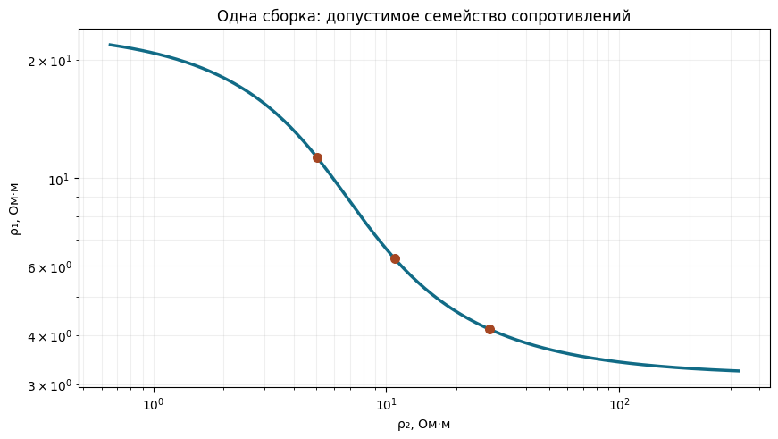

**Рисунок 1.** Ник, сборка 90 мм, задержка после вдоха. Сохранённая медиана равна **74.573 Ом**. При заданном **толщине 15 мм** все точки линии воспроизводят этот уровень в принятой модели. Три отмеченные точки — примеры равноправных решений, а не три оценки по независимым данным. Обе оси логарифмические. Толщина является сценарием, не результатом КТ-измерения.

## 4. Что добавляют другие размеры сборки

На рисунке 1 отмечены разные пары, удовлетворяющие одному измерению: выбирать одну из них по этой сборке оснований нет. Поэтому далее добавляются независимые размеры. При известной $h$ каждая сборка даёт свою кривую на той же плоскости. Общее пересечение означает, что одна пара сопротивлений воспроизводит все выбранные уровни в принятой модели. Для двух сборок локальная определимость требует независимых строк матрицы чувствительности:

$$J_{j\ell}=\frac{\partial F_j}{\partial\rho_\ell},\qquad \operatorname{rank}J=2, \tag{4}$$

где $J$ — матрица производных импеданса по двум сопротивлениям, $j$ нумерует сборки, а $\ell$ — слои. Условие ранга в формуле (4) проверяет локальное разделение параметров и не доказывает глобальную единственность решения.

Почти касающиеся кривые соответствуют слабому разделению двух параметров. Однако разброс пересечений может возникнуть и из-за несовпадения состояний между записями, ошибок установки, неверной толщины или недостаточности модели. Его нельзя автоматически назвать шумом либо доверительной областью.

Если общего пересечения нет, совместная подгонка ищет компромисс по выбранной мере остатков. Надо показывать остатки каждой сборки, параметры на границах и чувствительность решения к исключению записей. Вес по углу пересечения может быть геометрической эвристикой; он не заменяет модель неопределённости. Подробная постановка приведена в 30.02.

Рисунок 2 нужен для сравнения взаимного положения ограничений при разных толщинах. Он сохраняет все независимые размеры обоих испытуемых и меняет только заданную толщину. Используется состояние после вдоха. Искусственная общая точка и «лучший» размер не назначаются.

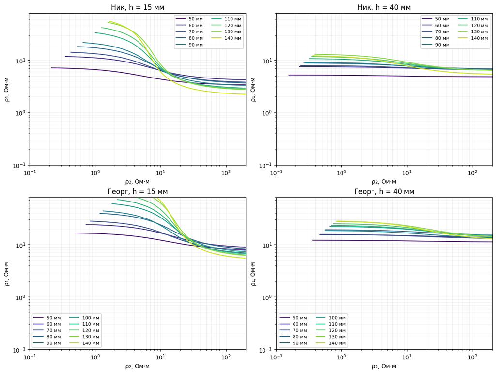

**Рисунок 2.** Семейства решений всех независимых размеров по сохранённым медианам после вдоха. Цвет обозначает размер; окна и логарифмические шкалы одинаковы. При смене заданной толщины положение и взаимное сближение кривых меняются. Пересечение отдельных линий ещё не означает общего решения всего размерного ряда. Для 351 выбранных точек максимальная относительная ошибка обратной подстановки составила 1.17e-15. Это проверка построения рисунка, а не точности тканевых оценок.

### Почему неизвестную толщину нельзя незаметно исключить

Рисунок 2 показывает, что кривые при большей заданной толщине на показанном участке становятся более пологими. Поэтому нужно различать информацию об отношении тканевых сопротивлений и ограничение на толщину. Если $h$ неизвестна, семейства меняются вместе с ней. Одна сборка тогда задаёт поверхность в пространстве трёх параметров, а две сборки в общем случае ещё не устраняют свободное направление. Хорошая подгонка при одной выбранной толщине не доказывает её анатомическую правильность.

В 33.06 исследуется профиль ошибки по толщине. Сохранённый разбор указывает на граничные решения и взаимную компенсацию параметров. Это отрицательный результат для данной постановки и её предпосылок; он не доказывает невозможность оценивать толщину при любых других данных. Полный новый атлас семейств описан и реализован в разделе 9 текущего исходного ноутбука. До его выполнения наличие кода не является наличием нового результата.

## 5. Дыхательные изменения — разность двух состояний

Для вдоха и выдоха следует сначала записать две самостоятельные статические задачи. Каждая имеет свои $Z_j$, а в общей постановке — свои $\rho_1,\rho_2,h$. После их условного решения определяются конечные разности:

$$\Delta\rho_\ell^{\mathrm{дых}}=\rho_{\ell,\mathrm{вдох}}-\rho_{\ell,\mathrm{выдох}},\qquad \ell=1,2, \tag{5}$$

где индексы обозначают сопоставляемые дыхательные состояния. Знак в формуле (5) соответствует разности «вдох минус выдох».

В текущем исследовательском расчёте 33.06 между состояниями приняты общие $h$ и $\rho_1$. Допущение $\rho_{1,\mathrm{вдох}}=\rho_{1,\mathrm{выдох}}$ непосредственно задаёт $\Delta\rho_1^{\mathrm{дых}}=0$. Постоянство $h$ является отдельным ограничением и само по себе не обнуляет $\Delta\rho_1^{\mathrm{дых}}$. Оба ограничения уменьшают число неизвестных. Нулевое дыхательное изменение верхнего слоя из такого расчёта нельзя объявлять экспериментальным результатом. Чтобы оценить обе дыхательные компоненты, надо проверить более полную постановку либо обосновать это сокращение на независимом референсе.

Изменение толщины также может менять импеданс. Подтверждённые автором диапазоны полного изменения толщины — до 1 мм при обычном и до 2 мм при глубоком дыхании — не означают симметричные интервалы ±1 и ±2 мм. Их влияние и отличие состояния электрической записи от КТ на глубоком вдохе требуют отдельного анализа. Для конечной дыхательной разности нельзя без проверки заменять прямую модель пульсовой линеаризацией.

## 6. Пульсовые изменения — две прямые приращений

Пульсовая задача начинается после выбора базовых сопротивлений и дыхательного состояния. ЭКГ задаёт временную привязку, но не разделяет источники сигнала в мягких тканях и лёгком. Ансамбли разных сборок должны соответствовать сопоставимой фазе и одной принятой операции обработки. Физиологическая задержка относительно зубца R допустима и должна учитываться.

Для малых изменений около базовой точки при фиксированной геометрии используется линеаризация:

$$\Delta Z_j(\tau)\approx J_{j1}\Delta\rho_1^{\mathrm{пульс}}(\tau) +J_{j2}\Delta\rho_2^{\mathrm{пульс}}(\tau), \tag{6}$$

где $\tau$ — согласованное время или фаза, $\Delta Z_j$ выражено в Ом, $J_{j\ell}$ — в м$^{-1}$, а $\Delta\rho_\ell$ — в Ом·м.

При ненулевом $J_{j1}$ одна сборка задаёт прямую:

$$\Delta\rho_1^{\mathrm{пульс}}= \frac{\Delta Z_j-J_{j2}\Delta\rho_2^{\mathrm{пульс}}}{J_{j1}}, \tag{7}$$

где обе производные вычислены в одной выбранной базовой точке. Уравнение (7) выражает верхнюю тканевую компоненту через нижнюю при фиксированном наблюдаемом приращении.

Две независимые строки чувствительности позволяют разделить два приращения **внутри этой линейной модели**. При существенном изменении толщины, положения или контакта в уравнение должны входить соответствующие дополнительные вклады. Ошибка базовых сопротивлений меняет саму матрицу $J$; её нельзя оценивать отдельно и затем забывать.

На рисунке 3 проверяется восстановление заранее известной пары. Для этого задаются два известных приращения, по ним рассчитываются синтетические изменения импеданса и восстанавливается пересечение прямых. Это самоконтроль математической схемы. Реальные пульсовые значения здесь не пересчитываются. Общая постановка описана в 30.03, а экспериментальные ансамбли и условная инверсия — в 33.03 и 33.04.

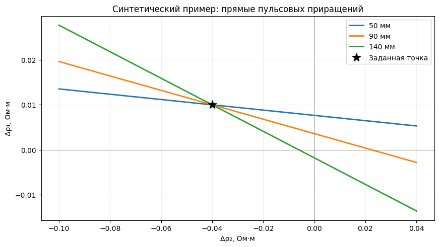

**Рисунок 3.** Синтетический расчёт при ρ₁ = 10 Ом·м, ρ₂ = 30 Ом·м и толщине 15 мм. Заданы Δρ₁ = 0.01 Ом·м и Δρ₂ = -0.04 Ом·м. Пересечение восстанавливает (0.010; -0.040) Ом·м. Максимальное различие конечного изменения прямой модели и линейного приближения здесь равно 1.45e-04 Ом. Эта величина относится только к заданной базовой точке и величине возмущения; она не задаёт общую допустимую ошибку.

### Что восстановлено из прежнего ноутбука и что пересмотрено

На рисунке 3 прямые пересекаются в заданной точке, поскольку данные специально построены тем же линейным оператором. Для экспериментальных сигналов такая согласованность заранее не обеспечена. Поэтому перед переносом схемы нужно проверить способ получения правой части уравнения (6).

Связная последовательность найдена в историческом 33.91: ячейка `4836dc01` строит кривые решений по базовому импедансу, а ячейка `def1cc31` — прямые для пульсовых приращений. В первом рисунке старого ноутбука оси расположены наоборот: по горизонтали $\rho_1$, по вертикали $\rho_2$. Математическое множество то же.

В прежней пульсовой реализации в правую часть подставлен размах усреднённого сигнала «максимум минус минимум». Он не сохраняет знак изменения относительно выбранной базы; экстремумы разных сборок могут соответствовать разным фазам. При двух тканевых источниках размах суммы также нельзя в общем случае заменить суммой размахов. Поэтому полученные таким способом знаки тканевых приращений не подтверждают их физиологическую направленность.

Попарные пересечения дополнительно усреднялись с весами по квадрату синуса угла между прямыми. Они зависимы, потому что используют повторяющиеся записи. Разброс такого облака не является автоматически стандартной ошибкой, а малая компонента не доказана равной нулю. Геометрическая иллюстрация сохраняется; старые выводы о разделённых тканевых источниках требуют повторной проверки с согласованными сигналами.

## 7. Текущее состояние и незакрытые переходы

Ниже разделены наличие материала и доказанность его интерпретации. Подробные результаты и очередь работ сохраняются у владельцев этапов, прежде всего в 34.05. Эта таблица — краткий срез для чтения методики.

**Таблица 3.** Состояние переходов и необходимые проверки.

| Переход | Что выполнено | Что ещё требуется | Статус |
| --- | --- | --- | --- |
| Запись → базовые уровни эксперимента 2 | Есть независимый размерный ряд, принятая ретроспективная разметка и сохранённые агрегаты | Оценить влияние границ интервалов, порядка записи и повторной установки | Результат обработки при явных допущениях |
| Анатомия → оператор боковой сборки | Есть КТ/FEM и сравнения геометрических упрощений | Согласовать референсное место и контакты; проверить сокращённую модель на известных параметрах | Разработка и модельные проверки; 34.05 |
| Базовые уровни → $\rho_1,\rho_2$ | Реализованы инверсия, профили и семейства решений | Связать толщину с КТ, проверить остатки и устойчивость по независимым размерам | Условный модельный результат; 33.06 |
| Два дыхательных состояния → оба $\Delta\rho$ | Есть подгонка с общей толщиной и общим сопротивлением верхнего слоя | Проверить цену этих ограничений; оценить обе компоненты без заранее заданного нуля | Полная постановка не закрыта |
| Пульсовой сигнал → оба $\Delta\rho$ | Есть ансамбли и условная инверсия | Согласовать обработку и фазу; передать ошибку базовой точки в чувствительности; проверить конечные изменения | Точность разделения не установлена; 34.04 |
| Полный размерный ряд → рабочая пара | Есть анализ чувствительности и критерии выбора | Выбирать пару после проверки полной модели и испытывать на неиспользованных размерах и состояниях | Две сборки остаются целевой постановкой; 32.02 |
| Эксперимент 2 → эксперимент 3 | Описаны ревизии и выявлена зависимость каналов в тесте отключения | Для записей РНЦХ принять дыхательную и ЭКГ-разметку, разобраться с длительными предельными уровнями | Автоматический перенос пульсовых выводов недопустим |
| Тканевые вклады → ТТРКГ → функции сердца | Сформулирована цепочка и имеются расчёты чувствительности | Проверить оператор переноса, разделить движение и изменение объёма, связать результат с нужной камерой | Программа разработки, не валидированная методика УО/ФВ |

**Приоритет связанной проверки:** на одном согласованном КТ-референсе задать известные тканевые параметры, сравнить полную и сокращённую прямые модели, выполнить базовую инверсию и передать её ошибку в дыхательную и пульсовую части. Затем проверить выбранное правило на других размерах, состояниях и анатомиях. Этот порядок уже обоснован в 34.05; новая сводка его не заменяет.

Отдельно надо согласовать текущие форматы пульсовых артефактов: наличие расчёта в 33.04 не доказывает, что он использует ту же операцию усреднения и временную шкалу, что другие версии серии. Первая серия на РЕО32 не включена в эту цепочку из-за другого прибора и монтажа.

## 8. Как поддерживать этот ноутбук

После содержательного изменения профильного расчёта здесь обновляются затронутый переход, краткий результат, его ограничения и ссылка на доказательство. Наличие нового файла или успешное завершение программы не повышает статус результата автоматически. Изменение вывода сопровождается объяснением причины; отрицательные результаты сохраняются.

Встроенная таблица измерений является зафиксированным извлечением. Её не следует незаметно заменять при повторном запуске. Для обновления надо выбрать новый проверенный артефакт, сверить состав записей и заменить данные вместе с их происхождением. Контроль ниже сравнивает версии опорных документов; он лишь сообщает, что повествование может нуждаться в пересмотре, и не принимает научных решений.

Для воспроизведения иллюстраций ячейки выполняются сверху вниз в новом ядре Python из этой папки либо корня репозитория. Общие зависимости перечислены в файле окружения. Нужны численные библиотеки, средства построения графиков и чтения ноутбука; исходные физиологические записи не загружаются. Случайные величины здесь не генерируются. При изменении используемых функций прямой модели запуск останавливается до содержательной сверки. Отчёт предназначен для чтения и проверки логики, а не для передачи своих иллюстративных параметров в последующие физиологические расчёты.

**Требуется сверка повествования:** изменились опорные материалы. Сохранённый статус нельзя автоматически считать текущим.

- 33.06

- 33.91

## 9. Что даёт восстановленная последовательность

Геометрия решения теперь показана явно: один базовый импеданс задаёт кривую, несколько размеров проверяют совместимость кривых, а пульсовая линеаризация задаёт прямые для двух приращений. Это позволяет видеть, какая информация действительно добавлена на каждом шаге и какое ограничение лишь принято в модели.

Остаётся проверить анатомический оператор, совместно оценить две дыхательные компоненты и передать ошибку базовой точки в пульсовую инверсию. До их проверки условные тканевые параметры не становятся независимо измеренными свойствами тканей. Следующий переход к коррекции ТТРКГ и УО/ФВ требует собственных физических операторов и референсных проверок.